[figure not shown]

# Social Media Addiction – Analiza danych

Dawid Drawc

2026-02-17

# 1. Wprowadzenie

W tym raporcie sprawdzam, czy sposób korzystania z mediów społecznościowych wiąże się ze snem, uzależnieniem oraz tym, czy studenci czują wpływ na naukę. Dane m.in. średni dzienny czas w social mediach w godzinach, liczbę godzin snu, wynik uzależnienia oraz odpowiedź „Yes/No” o wpływie na naukę.

## Cel i pytania badawcze

Celem raportu jest sprawdzenie, jak średni dzienny czas korzystania z social mediów (`czas_sm_godz`) wiąże się z:

- poziomem uzależnienia (`wynik_uzaleznienia`),
- snem (`sen_godz`),
- zdrowiem psychicznym (`zdrowie_psychiczne`),
- konfliktami przez social media (`konflikty_przez_sm`),
- deklaracją wpływu na wyniki w nauce (`wplywa_na_nauke`, Yes/No).

Pytania badawcze:

1. Czy osoby z wyższym czasem korzystania mają wyższy poziom uzależnienia?
2. Czy wyższy czas korzystania wiąże się z krótszym snem?
3. Czy wyższy czas korzystania wiąże się z gorszym zdrowiem psychicznym?
4. Czy wyższy czas korzystania wiąże się z większą liczbą konfliktów?
5. Czy osoby, które mówią „Yes” (wpływa na naukę), różnią się od „No” (czas, sen, uzależnienie itp.)?

```r
info <- data.frame(
  "Liczba wierszy" = nrow(data),
  "Liczba kolumn" = ncol(data),
  check.names = FALSE
)

kable(info, align = "l") %>%
  kable_styling(full_width = FALSE, position = "left")
```

| Liczba wierszy | Liczba kolumn |
| --- | --- |
| 705 | 13 |

```r
kolumny <- data.frame(
  Nr = 1:ncol(data),
  "Nazwa kolumny" = names(data),
  check.names = FALSE
)
kable(kolumny, align = "l") %>%
  kable_styling(full_width = FALSE, position = "left")
```

| Nr | Nazwa kolumny |
| --- | --- |
| 1 | id_studenta |
| 2 | wiek |
| 3 | plec |
| 4 | poziom_nauki |
| 5 | kraj |
| 6 | czas_sm_godz |
| 7 | platforma |
| 8 | wplywa_na_nauke |
| 9 | sen_godz |
| 10 | zdrowie_psychiczne |
| 11 | status_zwiazku |
| 12 | konflikty_przez_sm |
| 13 | wynik_uzaleznienia |

# 2. Data Cleansing, Wrangling

## 2.1 Braki danych i duplikaty

```r
# Ile jest NA w całym zbiorze?
suma_na <- sum(is.na(data))

suma_na <- data.frame(
  "Łączna liczba brakujących danych (NA)" = suma_na,
  check.names = FALSE
)

kable(suma_na, align = "l") %>%
  kable_styling(full_width = FALSE, position = "left")
```

| Łączna liczba brakujących danych (NA) |
| --- |
| 0 |

```r
# Braki w kolumnach
braki_kolumny <- data.frame(
  "Nazwy Id" = names(data),
  "Liczba na" = colSums(is.na(data)),
  check.names = FALSE
)


kable(braki_kolumny, align = "l", row.names = FALSE) %>%
  kable_styling(full_width = FALSE, position = "left")
```

| Nazwy Id | Liczba na |
| --- | --- |
| id_studenta | 0 |
| wiek | 0 |
| plec | 0 |
| poziom_nauki | 0 |
| kraj | 0 |
| czas_sm_godz | 0 |
| platforma | 0 |
| wplywa_na_nauke | 0 |
| sen_godz | 0 |
| zdrowie_psychiczne | 0 |
| status_zwiazku | 0 |
| konflikty_przez_sm | 0 |
| wynik_uzaleznienia | 0 |

```r
# Czy id_studenta się duplikuje
duplikaty_id <- data %>%
  count(id_studenta) %>%
  filter(n > 1)

kable(duplikaty_id)
```

| id_studenta | n |
| --- | --- |

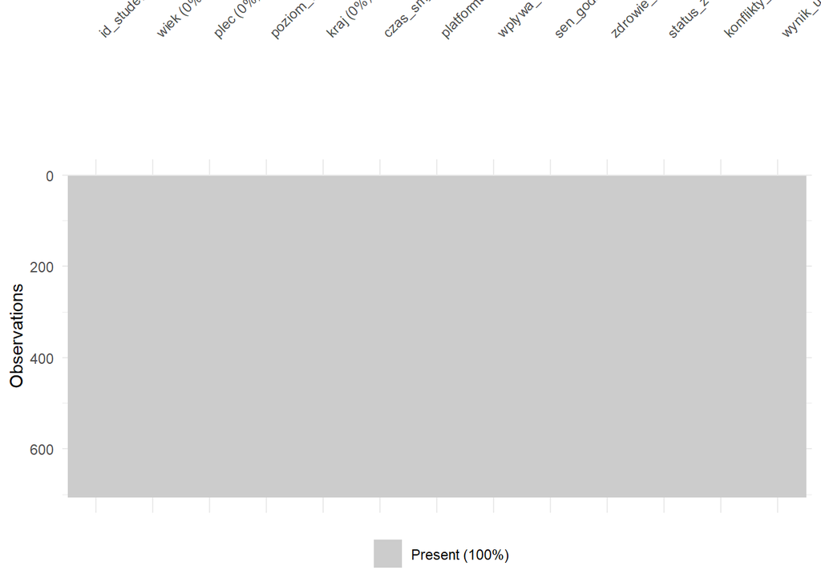

Braki danych i duplikaty

```r
vis_miss(data)
```

Najpierw przygotowałem dane i zrobiłem podstawowy opis. Potem sprawdziłem zależności korelacjami i testami różnic między grupami. Na końcu zbudowałem modele regresję liniową dla snu oraz model logitowy dla deklarowanego wpływu na naukę. Trzeba pamiętać, że to dane z jednego momentu, więc pokazują zależności, ale nie dowodzą przyczyny.

## 2.2 Przedstawienie typów danych porządkowanie kategorii za pomocą tabeli

```r
data2 <- data %>%
  mutate(
    plec = factor(plec),
    poziom_nauki = factor(poziom_nauki, levels = c("High School", "Undergraduate", "Graduate")),
    status_zwiazku = factor(status_zwiazku),
    platforma = factor(platforma),
    wplywa_na_nauke = factor(wplywa_na_nauke, levels = c("No", "Yes"))
  )


tab <- gtsummary::tbl_summary(data2)

tab %>%
  gtsummary::as_kable_extra() %>%
  scroll_box(height = "400px")
```

| Characteristic | N = 705 |
| --- | --- |
| id_studenta | 353 (177, 529) |
| wiek |  |
| 18 | 14 (2.0%) |
| 19 | 163 (23%) |
| 20 | 165 (23%) |
| 21 | 156 (22%) |
| 22 | 147 (21%) |
| 23 | 34 (4.8%) |
| 24 | 26 (3.7%) |
| plec |  |
| Female | 353 (50%) |
| Male | 352 (50%) |
| poziom_nauki |  |
| High School | 27 (3.8%) |
| Undergraduate | 353 (50%) |
| Graduate | 325 (46%) |
| kraj |  |
| Afghanistan | 1 (0.1%) |
| Albania | 1 (0.1%) |
| Andorra | 1 (0.1%) |
| Argentina | 1 (0.1%) |
| Armenia | 1 (0.1%) |
| Australia | 14 (2.0%) |
| Austria | 1 (0.1%) |
| Azerbaijan | 1 (0.1%) |
| Bahamas | 1 (0.1%) |
| Bahrain | 1 (0.1%) |
| Bangladesh | 20 (2.8%) |
| Belarus | 1 (0.1%) |
| Belgium | 1 (0.1%) |

[output cut: 140 more lines]

<sup>1</sup> Median (Q1, Q3); n (%)

Dane zawierają zmienne liczbowe wiek, czas w social mediach, sen, wynik uzależnienia, zdrowie psychiczne oraz zmienne kategoryczne płeć, poziom nauki, kraj, platforma, status związku i wpływ na naukę Yes/No. Dla analizy uporządkowałem kategorie tam, gdzie to było potrzebne, żeby później wykresy i tabele były czytelne.

### 2.3 Mapa pochodzenia ankietowanych

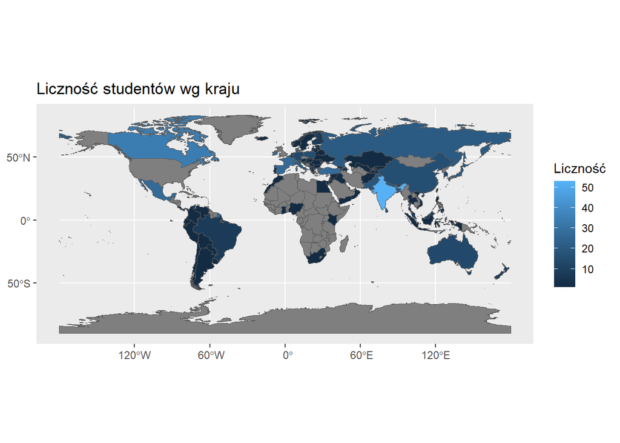

Mapa pochodzenia ankietowanych

```r
kraje_licznosc <- data2 %>%
  count(kraj, name = "licznosc")

world <- rnaturalearth::ne_countries(scale = "medium", returnclass = "sf")

mapa <- world %>%
  left_join(kraje_licznosc, by = c("name" = "kraj"))

ggplot(mapa) +
  geom_sf(aes(fill = licznosc)) +
  labs(title = "Liczność studentów wg kraju", fill = "Liczność")
```

## 2.4 Nowe zmienne do analizy

```r
data3 <- data2 %>%
  mutate(
    grupa_uzycia = cut(
      czas_sm_godz,
      breaks = c(0, 2, 4, 6, 8, 10, Inf),
      labels = c("0-2", "2-4", "4-6", "6-8", "8-10", ">10"),
      include.lowest = TRUE
    ),
    niski_sen = if_else(sen_godz < 7, "<7h", ">=7h") %>% factor()
  )
```

Dodałem dwie nowe zmienne: `grupa_uzycia`, która dzieli czas korzystania z social media na kategorie oraz `niski_sen`, która klasyfikuje osoby na te, które śpią mniej niż 7 godzin i te, które śpią 7 lub więcej godzin. To pozwoli mi później sprawdzić, czy są różnice między tymi grupami w kontekście snu i uzależnienia.

## 2.5 Sprawdzenie nowych zmiennych

```r
tabela_grupa_uzycia <- as.data.frame(table(data3$grupa_uzycia))

colnames(tabela_grupa_uzycia) <- c("Przedziały czasowe korzystania z social media", "Liczba osób")

kable(tabela_grupa_uzycia, align = "l") %>%
  kable_styling(full_width = FALSE, position = "left")
```

| Przedziały czasowe korzystania z social media | Liczba osób |
| --- | --- |
| 0-2 | 2 |
| 2-4 | 167 |
| 4-6 | 393 |
| 6-8 | 138 |
| 8-10 | 5 |
| >10 | 0 |

```r
tabela_niski_sen <- as.data.frame(table(data3$niski_sen))

colnames(tabela_niski_sen) <- c("Czas snu", "Liczba osób")

kable(tabela_niski_sen, align = "l") %>%
  kable_styling(full_width = FALSE, position = "left")
```

| Czas snu | Liczba osób |
| --- | --- |
| <7h | 359 |
| >=7h | 346 |

Sprawdziłem, czy nowe zmienne mają sens i czy liczności się zgadzają z całą próbą. W grupach czasu korzystania wyszło 0–2h = 2 osoby, 2–4h = 167, 4–6h = 393, 6–8h = 138, 8–10h = 5 osób. W podziale snu wyszło: <7h = 359 osób, a ≥7h = 346 osób. Suma w obu przypadkach zgadza się do 705.

# 3. Wizualizacja danych

## 3.1 Rozkłady

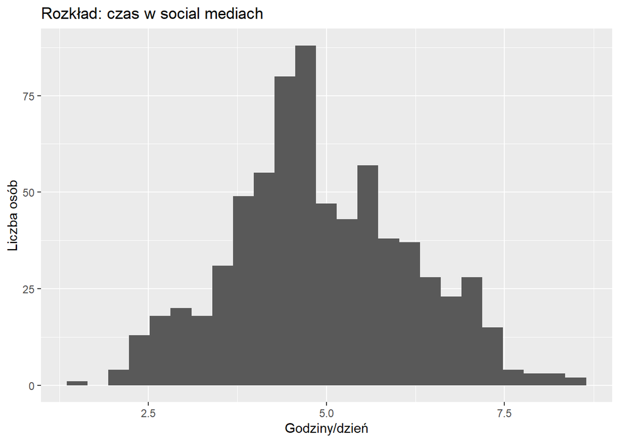

Histogramy czasu i snu

```r
ggplot(data3, aes(x = czas_sm_godz)) +
  geom_histogram(bins = 25) +
  labs(title = "Rozkład: czas w social mediach", x = "Godziny/dzień", y = "Liczba osób")
```

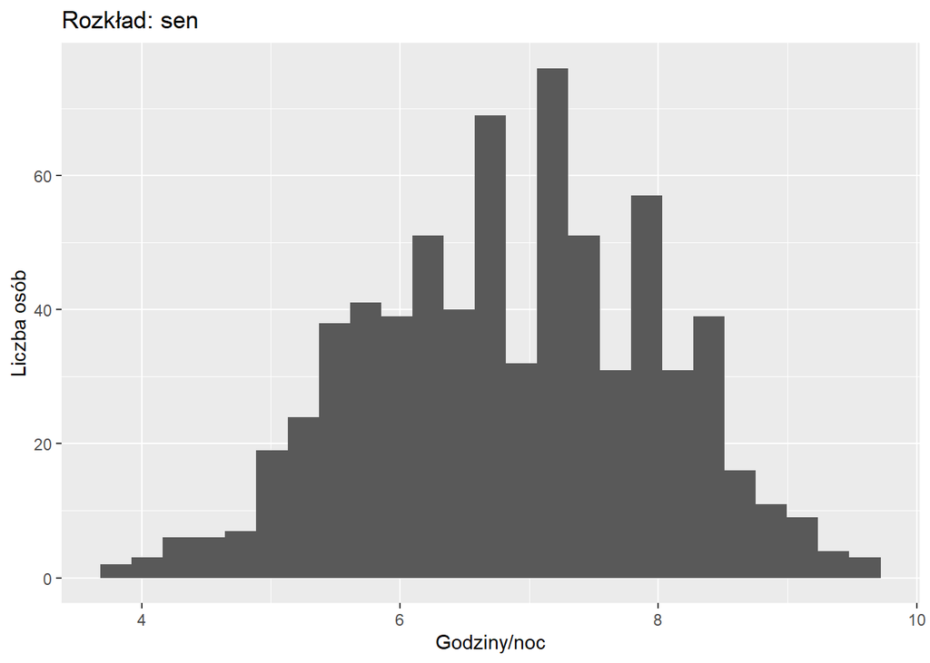

Histogramy czasu i snu

```r
ggplot(data3, aes(x = sen_godz)) +
  geom_histogram(bins = 25) +
  labs(title = "Rozkład: sen", x = "Godziny/noc", y = "Liczba osób")
```

Widać, że czas w social mediach najczęściej kręci się w okolicach 4–6 godzin dziennie. Najwięcej słupków jest właśnie w tym środku, a im bliżej skrajów, czyli gdy ktoś korzysta bardzo mało albo bardzo dużo, tym osób jest mniej. Dla snu widać, że większość osób śpi około 6–8 godzin. Największe zagęszczenie jest blisko 7 godzin, a mało jest osób śpiących bardzo krótko np. poniżej 5 albo bardzo długo powyżej 9 godzin.

## 3.2 Zależność: czas w social mediach vs sen

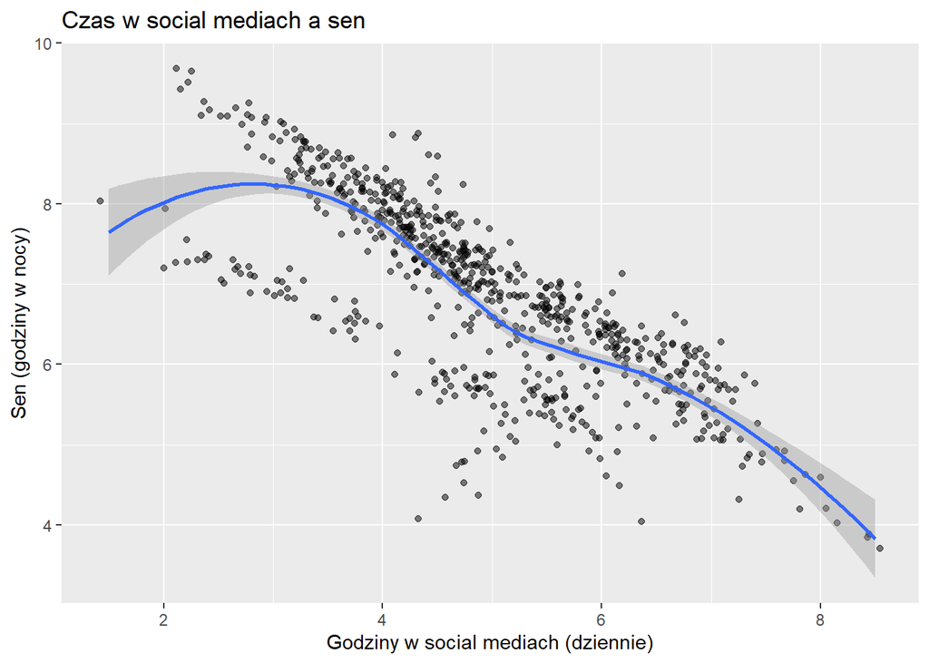

Czas w social mediach a sen

```r
ggplot(data3, aes(x = czas_sm_godz, y = sen_godz)) +
  geom_jitter(alpha = 0.5, width = 0.2, height = 0.2) +
  geom_smooth(method = "loess", formula = y ~ x, se = TRUE) +
  labs(title = "Czas w social mediach a sen",
       x = "Godziny w social mediach (dziennie)",
       y = "Sen (godziny w nocy)")
```

Na wykresie widać wyraźny trend: im więcej czasu w social mediach, tym mniej snu. To nie jest idealna linia, ale kierunek jest mocny i powtarzalny. Już na etapie wizualizacji widać, że większe używanie social mediów często idzie w parze z krótszym snem.

## 3.3 Porównania grup

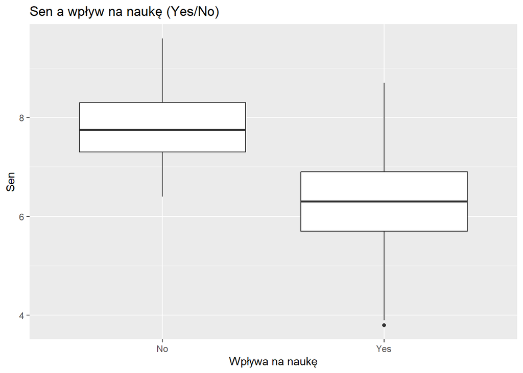

Boxploty porównań grup

```r
ggplot(data3, aes(x = wplywa_na_nauke, y = sen_godz)) +
  geom_boxplot() +
  labs(title = "Sen a wpływ na naukę (Yes/No)", x = "Wpływa na naukę", y = "Sen")
```

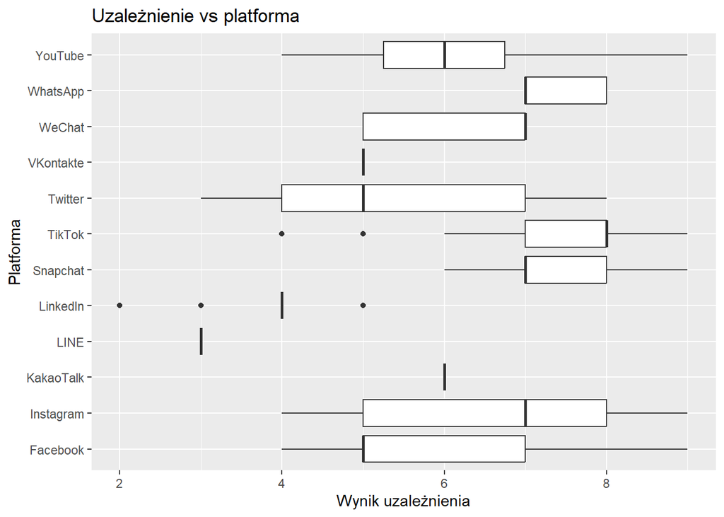

Boxploty porównań grup

```r
ggplot(data3, aes(x = platforma, y = wynik_uzaleznienia)) +
  geom_boxplot() +
  coord_flip() +
  labs(title = "Uzależnienie vs platforma", x = "Platforma", y = "Wynik uzależnienia")
```

## 3.4 Grupy użycia i niski sen

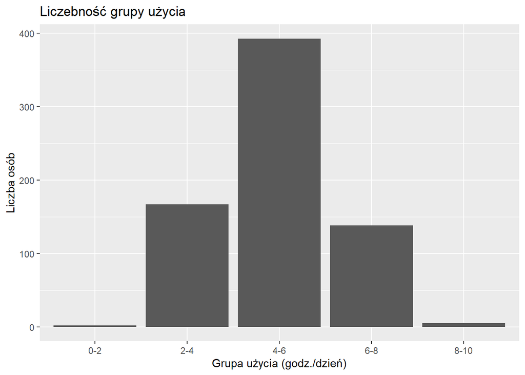

Grupy użycia i niski sen

```r
# Wykres słupkowy: Ilość grup użycia
ggplot(data3, aes(x = grupa_uzycia)) +
  geom_bar() +
  labs(title = "Liczebność grupy użycia", x = "Grupa użycia (godz./dzień)", y = "Liczba osób")
```

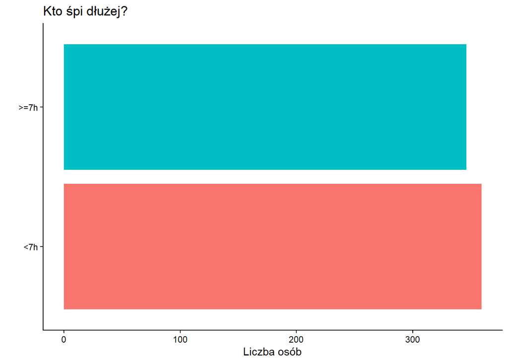

Grupy użycia i niski sen

```r
# Wykres słupkowy: Niski sen
ggplot(data3, aes(x = niski_sen, fill = niski_sen)) +
  geom_bar(show.legend = FALSE) +
  coord_flip() + # Obrócenie wykresu
  theme_classic() +
  labs(title = "Kto śpi dłużej?", x = "", y = "Liczba osób")
```

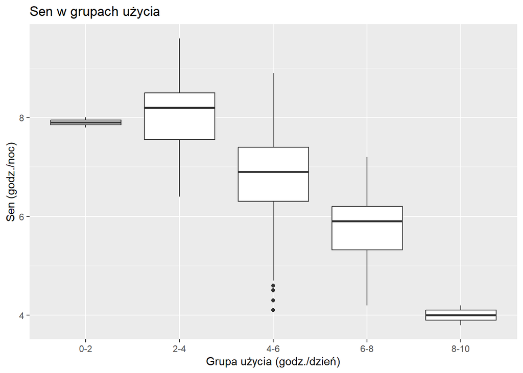

Grupy użycia i niski sen

```r
# Boxplot: Sen w grupach użycia
ggplot(data3, aes(x = grupa_uzycia, y = sen_godz)) +
  geom_boxplot() +
  labs(title = "Sen w grupach użycia", x = "Grupa użycia (godz./dzień)", y = "Sen (godz./noc)")
```

Po połączeniu grup czasu korzystania z podziałem snu widać, że osoby z większych przedziałów czasu częściej wpadają do grupy <7h snu. W praktyce wygląda to tak, że wraz ze wzrostem godzin w social mediach rośnie odsetek osób z „niskim snem”. To jest spójne z tym, co potem wychodzi w testach i korelacjach.

# 4. Analiza opisowa

## 4.1 Ogólna tabela opisowa

```r
# Oglna tabela opisowa

opis_danych <- data.frame(
  "Nazwa zmiennej" = names(data3),
  "Typ danych" = sapply(data3, class),
  "Przyklady" = sapply(data3, function(x) paste0(head(x, 3), collapse = ", ")),
  check.names = FALSE
)

kable(opis_danych, row.names = FALSE, align = "l") %>%
  kable_styling(
    bootstrap_options = c("striped", "hover", "condensed"),
    full_width = FALSE,
    position = "left"
  )
```

| Nazwa zmiennej | Typ danych | Przyklady |
| --- | --- | --- |
| id_studenta | integer | 1, 2, 3 |
| wiek | integer | 19, 22, 20 |
| plec | factor | Female, Male, Female |
| poziom_nauki | factor | Undergraduate, Graduate, Undergraduate |
| kraj | character | Bangladesh, India, USA |
| czas_sm_godz | numeric | 5.2, 2.1, 6 |
| platforma | factor | Instagram, Twitter, TikTok |
| wplywa_na_nauke | factor | Yes, No, Yes |
| sen_godz | numeric | 6.5, 7.5, 5 |
| zdrowie_psychiczne | integer | 6, 8, 5 |
| status_zwiazku | factor | In Relationship, Single, Complicated |
| konflikty_przez_sm | integer | 3, 0, 4 |
| wynik_uzaleznienia | integer | 8, 3, 9 |
| grupa_uzycia | factor | 4-6, 2-4, 4-6 |
| niski_sen | factor | <7h, >=7h, <7h |

```r
# Kategorie
kable_wplywa <- as.data.frame(table(data3$wplywa_na_nauke))
kable(kable_wplywa, align = "l") %>%
  kable_styling(full_width = FALSE, position = "left")
```

| Var1 | Freq |
| --- | --- |
| No | 252 |
| Yes | 453 |

```r
kable_plec <- as.data.frame(table(data3$plec))
kable(kable_plec, align = "l") %>%
  kable_styling(full_width = FALSE, position = "left")
```

| Var1 | Freq |
| --- | --- |
| Female | 353 |
| Male | 352 |

```r
kable_platforma <- as.data.frame(table(data3$platforma))
kable(kable_platforma, align = "l") %>%
  kable_styling(full_width = FALSE, position = "left")
```

| Var1 | Freq |
| --- | --- |
| Facebook | 123 |
| Instagram | 249 |
| KakaoTalk | 12 |
| LINE | 12 |
| LinkedIn | 21 |
| Snapchat | 13 |
| TikTok | 154 |
| Twitter | 30 |
| VKontakte | 12 |
| WeChat | 15 |
| WhatsApp | 54 |
| YouTube | 10 |

```r
# Podstawowe statystyki
stat_podst <- data.frame(
  Zmienna = c("czas_sm_godz", "sen_godz", "wynik_uzaleznienia"),
  Średnia = c(mean(data3$czas_sm_godz), mean(data3$sen_godz), mean(data3$wynik_uzaleznienia)),
  Odchylenie_sd = c(sd(data3$czas_sm_godz), sd(data3$sen_godz), sd(data3$wynik_uzaleznienia))
)
kable(stat_podst, align = "l") %>%
  kable_styling(full_width = FALSE, position = "left")
```

| Zmienna | Średnia | Odchylenie_sd |
| --- | --- | --- |
| czas_sm_godz | 4.918723 | 1.257394 |
| sen_godz | 6.868936 | 1.126848 |
| wynik_uzaleznienia | 6.436879 | 1.587165 |

```r
# Mediany i Kwartyle
stat_kwartyle <- data.frame(
  Zmienna = c("czas_sm_godz", "sen_godz"),
  Mediana = c(median(data3$czas_sm_godz), median(data3$sen_godz)),
  Q1 = c(quantile(data3$czas_sm_godz, 0.25), quantile(data3$sen_godz, 0.25)),
  Q3 = c(quantile(data3$czas_sm_godz, 0.75), quantile(data3$sen_godz, 0.75))
)
kable(stat_kwartyle, align = "l") %>%
  kable_styling(full_width = FALSE, position = "left")
```

| Zmienna | Mediana | Q1 | Q3 |
| --- | --- | --- | --- |
| czas_sm_godz | 4.8 | 4.1 | 5.8 |
| sen_godz | 6.9 | 6.0 | 7.7 |

W badaniu było prawie równo kobiet i mężczyzn: 353 kobiety i 352 mężczyzn. Najczęściej wskazywane platformy to Instagram (249), TikTok (154) i Facebook (123). Jeśli chodzi o wpływ na naukę, to 453 osoby odpowiedziały „Yes”, a 252 „No”, czyli większość studentów deklaruje, że social media wpływają na ich naukę.

## 4.2 Tabela opisowa w grupach

```r
wynik_opis <- data3 %>%
  group_by(wplywa_na_nauke) %>%
  summarise(
    n = n(),
    srednia_czas_sm_godz = mean(czas_sm_godz),
    mediana_czas_sm_godz = median(czas_sm_godz),
    srednia_sen_godz = mean(sen_godz),
    mediana_sen_godz = median(sen_godz),
    srednia_wynik_uzaleznienia = mean(wynik_uzaleznienia),
    .groups = "drop"
  )

kable(t(wynik_opis)) %>%
  kable_styling(full_width = FALSE, position = "left")
```

| wplywa_na_nauke | No | Yes |
| --- | --- | --- |
| n | 252 | 453 |
| srednia_czas_sm_godz | 3.804365 | 5.538631 |
| mediana_czas_sm_godz | 3.9 | 5.5 |
| srednia_sen_godz | 7.813095 | 6.343709 |
| mediana_sen_godz | 7.75 | 6.30 |
| srednia_wynik_uzaleznienia | 4.595238 | 7.461369 |

# 5. Wnioskowanie

## 5.1 Korelacja i wykres zależność czasu w social mediach do długości snu

```r
korelacja <- cor.test(data3$czas_sm_godz, data3$sen_godz, method = "spearman", exact = FALSE)

korelacja_tabela <- broom::tidy(korelacja) %>%
  mutate(
    estimate = round(estimate, 3),
    p.value = format.pval(p.value, digits = 3, eps = 0.001)
  )

kable(t(korelacja_tabela)) %>%
  kable_styling(full_width = FALSE, position = "left")
```

| estimate | -0.814 |
| --- | --- |
| statistic | 105965906 |
| p.value | <0.001 |
| method | Spearman’s rank correlation rho |
| alternative | two.sided |

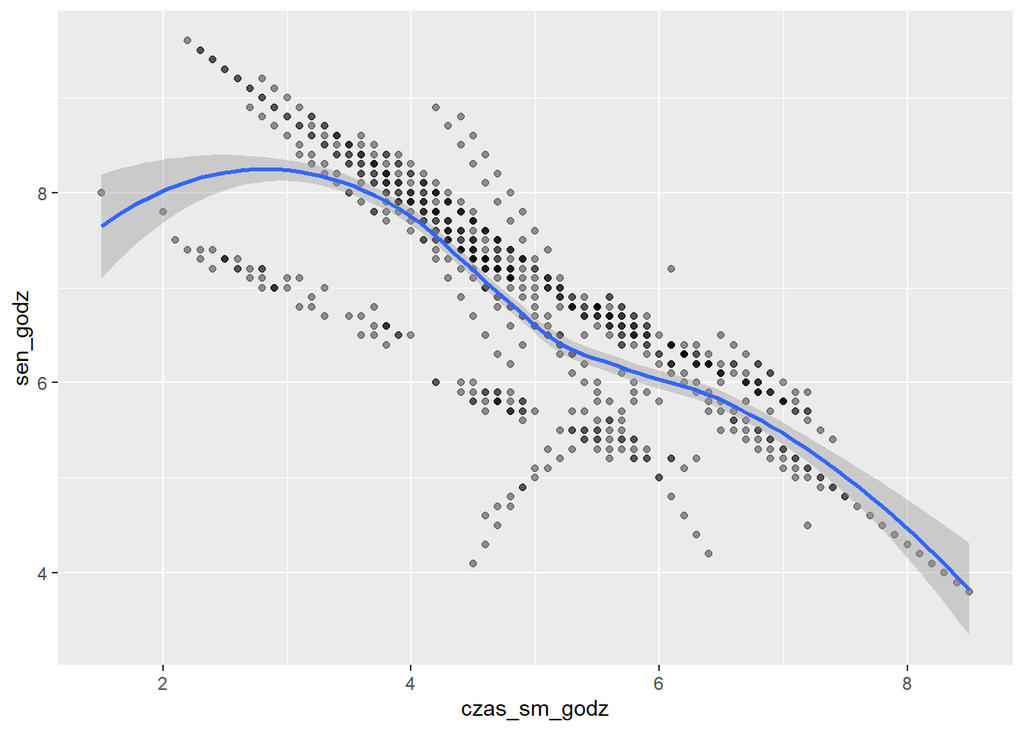

Zależność czasu w social mediach do długości snu

```r
ggplot(data3, aes(czas_sm_godz, sen_godz)) +
  geom_point(alpha = 0.4) +
  geom_smooth(method = "loess", formula = y ~ x, se = TRUE)
```

Użyłem korelacji Spearmana, bo to bezpieczne przy danych, które nie muszą być idealnie normalne. Wyszła bardzo silna ujemna zależność: rho = -0,814 i p-value < 0,001. To oznacza, że im więcej godzin w social mediach, tym krócej śpią badani. Związek jest mocny i trudno go tłumaczyć przypadkiem.

## 5.2 Korelacja i wykres zależność czasu w social mediach a wynikiem uzależnienia

```r
korelacja1 <- cor.test(data3$czas_sm_godz, data3$wynik_uzaleznienia, method = "spearman", exact = FALSE)

korelacja1_tabela <- broom::tidy(korelacja1) %>%
  mutate(
    estimate = round(estimate, 3),
    p.value = format.pval(p.value, digits = 3, eps = 0.001)
  )

kable(t(korelacja1_tabela)) %>%
  kable_styling(full_width = FALSE, position = "left")
```

| estimate | 0.838 |
| --- | --- |
| statistic | 9460991 |
| p.value | <0.001 |
| method | Spearman’s rank correlation rho |
| alternative | two.sided |

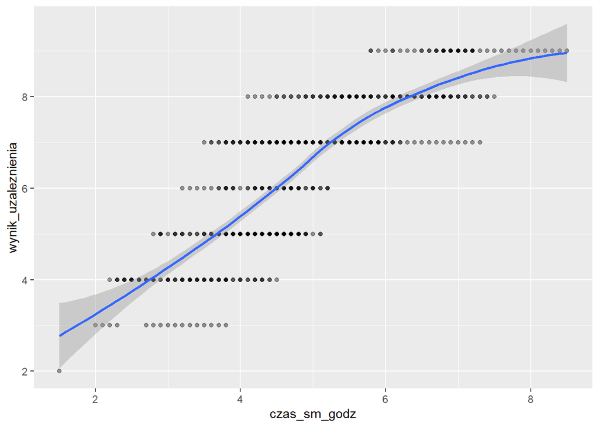

Zależność czasu w social mediach a wynikiem uzależnienia

```r
ggplot(data3, aes(czas_sm_godz, wynik_uzaleznienia)) +
  geom_point(alpha = 0.4) +
  geom_smooth(method = "loess", formula = y ~ x, se = TRUE)
```

Tutaj też wyszła silna dodatnia korelacja: rho = 0,838 i p-value < 0,001. To oznacza, że im więcej czasu w social mediach, tym wyższy wynik uzależnienia. Związek jest mocny i pokazuje, że czas korzystania jest ważnym czynnikiem związanym z poziomem uzależnienia.

## 5.3 Korelacja czasu i snu w podgrupach (Yes/No)

```r
korelacja2 <- data3 %>%
  group_by(wplywa_na_nauke) %>%
  summarise(
    n = n(),
    rho = cor(czas_sm_godz, sen_godz, method = "spearman"),
    p_value = format.pval(cor.test(czas_sm_godz, sen_godz, method="spearman", exact=FALSE)$p.value, digits = 3, eps = 0.001),
    .groups = "drop"
  )

kable(korelacja2) %>%
  kable_styling(full_width = FALSE, position = "left")
```

| wplywa_na_nauke | n | rho | p_value |
| --- | --- | --- | --- |
| No | 252 | -0.3758403 | <0.001 |
| Yes | 453 | -0.6722543 | <0.001 |

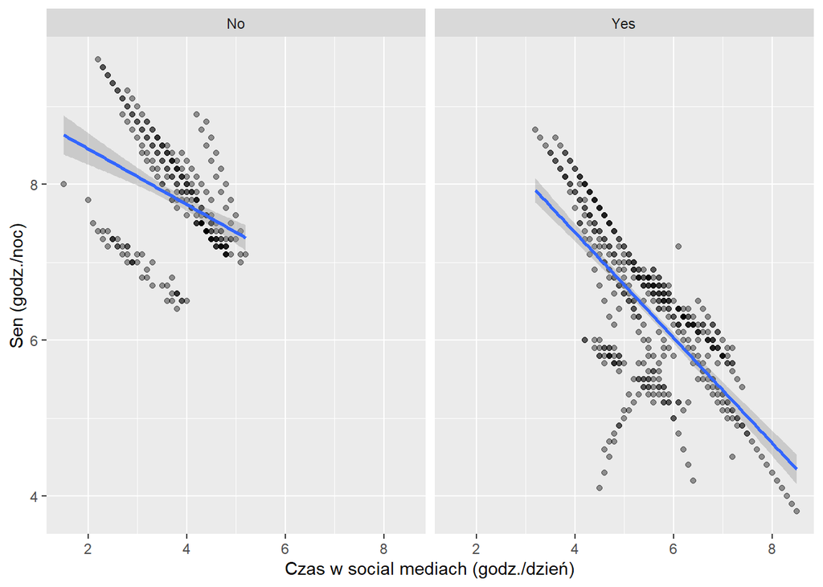

Zależność czasu w social mediach i długości snu w podgrupach (Yes/No)

```r
ggplot(data3, aes(czas_sm_godz, sen_godz)) +
  geom_point(alpha = 0.4) +
  geom_smooth(method = "lm", formula = y ~ x, se = TRUE) +
  facet_wrap(~ wplywa_na_nauke) +
  labs(x = "Czas w social mediach (godz./dzień)", y = "Sen (godz./noc)")
```

Sprawdziłem korelację czasu i snu osobno w grupach „No” i „Yes”. W grupie „No” wyszło rho = -0,376, a w grupie „Yes” rho = -0,672 (w obu przypadkach p-value < 0,001). To oznacza, że związek „więcej social mediów = mniej snu” jest dużo silniejszy u osób, które czują wpływ na naukę.

## 5.4 Test różnic: sen w grupie Yes vs No

```r
p <- tapply(data3$sen_godz, data3$wplywa_na_nauke, \(x) shapiro.test(x)$p.value)

p <- data.frame(
  grupa = names(p),
  p_shapiro = as.numeric(p)
)
kable(p, align = "l", caption = "Test Shapiro-Wilka w grupach (Yes/No)") %>%
  kable_styling(full_width = FALSE, position = "left")
```

Test Shapiro-Wilka w grupach (Yes/No)

| grupa | p_shapiro |
| --- | --- |
| No | 0.0003203 |
| Yes | 0.0180613 |

```r
if(all(p > 0.05)) {
  wynik <- t.test(sen_godz ~ wplywa_na_nauke, data = data3)
  efekt <- cohens_d(sen_godz ~ wplywa_na_nauke, data = data3)
} else {
  wynik <- wilcox.test(sen_godz ~ wplywa_na_nauke, data = data3)
  efekt <- wilcox_effsize(sen_godz ~ wplywa_na_nauke, data = data3)
}

wynik_tabela <- broom::tidy(wynik) %>%
  mutate(p.value = scales::pvalue(p.value, accuracy = 0.001))

kable(t(wynik_tabela), caption = "Wynik testu") %>%
  kable_styling(full_width = FALSE, position = "left")
```

Wynik testu

| statistic | 101118.5 |
| --- | --- |
| p.value | <0.001 |
| method | Wilcoxon rank sum test with continuity correction |
| alternative | two.sided |

```r
kable(efekt, align = "l", caption = "Wielkość efektu") %>%
  kable_styling(full_width = FALSE, position = "left")
```

Wielkość efektu

| .y. | group1 | group2 | effsize | n1 | n2 | magnitude |
| --- | --- | --- | --- | --- | --- | --- |
| sen_godz | No | Yes | 0.6402555 | 252 | 453 | large |

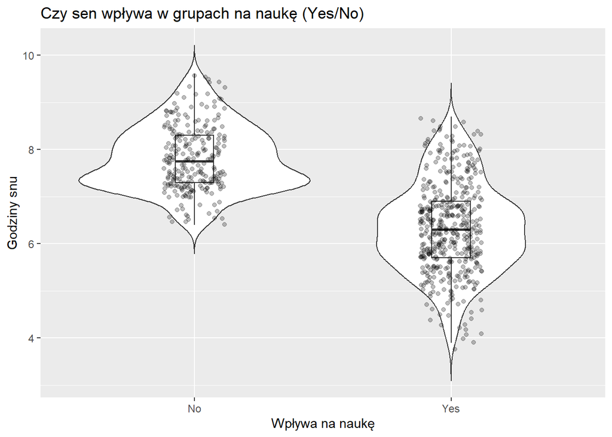

Różnice senu w grupie Yes vs No

```r
ggplot(data3, aes(x = wplywa_na_nauke, y = sen_godz)) +
  geom_violin(trim = FALSE) +
  geom_boxplot(width = 0.15, outlier.shape = NA) +
  geom_jitter(width = 0.12, alpha = 0.25) +
  labs(
    title = "Czy sen wpływa w grupach na naukę (Yes/No)",
    x = "Wpływa na naukę",
    y = "Godziny snu"
  )
```

Najpierw sprawdziłem normalność rozkładów i wyszło, że w obu grupach normalność nie jest spełniona (p-value Shapiro < 0,05). Dlatego użyłem testu Wilcoxona. Wynik był istotny (p-value < 0,001), więc grupa „Yes” rzeczywiście śpi krócej niż „No”. Dodatkowo efekt wyszedł duży (effsize ≈ 0,64, czyli duży), więc to nie jest mała różnica.

## 5.5 ANOVA: wynik uzaleznienia vs platforma

```r
fit <- aov(wynik_uzaleznienia ~ platforma, data = data3)

p_shapiro <- shapiro.test(residuals(fit))$p.value
p_bartlett <- bartlett.test(wynik_uzaleznienia ~ platforma, data = data3)$p.value

p_shapiro_fmt <- format.pval(p_shapiro, eps = 0.001, digits = 3)
p_bartlett_fmt <- format.pval(p_bartlett, eps = 0.001, digits = 3)

df_wynik <- data.frame(
  Shapiro_Wilk = p_bartlett_fmt,
  P_Value = p_bartlett_fmt
)

kable(df_wynik, align = "l", col.names = c("p-value Shapiro-Wilk", "p-value Bartlett"), digits = 10) %>%
  kable_styling(full_width = FALSE, position = "left")
```

| p-value Shapiro-Wilk | p-value Bartlett |
| --- | --- |
| <0.001 | <0.001 |

```r
if (p_shapiro > 0.05 && p_bartlett > 0.05) {
  wynik_anova <- broom::tidy(fit)
  wynik_tukey <- broom::tidy(TukeyHSD(fit))

  kable(wynik_anova, align = "l", caption = "ANOVA: wynik uzależnienia ~ platforma") %>%
    kable_styling(full_width = FALSE, position = "left")

  kable(wynik_tukey, align = "l", caption = "Tukey HSD: porównania par platform") %>%
    kable_styling(full_width = FALSE, position = "left")
} else {
  wynik_kruskal <- broom::tidy(kruskal.test(wynik_uzaleznienia ~ platforma, data = data3))
}
kable(t(wynik_kruskal), caption = "Kruskal-Wallis dla uzależnienia i platform") %>%
  kable_styling(full_width = FALSE, position = "left")
```

Kruskal-Wallis dla uzależnienia i platform

| statistic | 227.4015 |
| --- | --- |
| p.value | 1.478552e-42 |
| parameter | 11 |
| method | Kruskal-Wallis rank sum test |

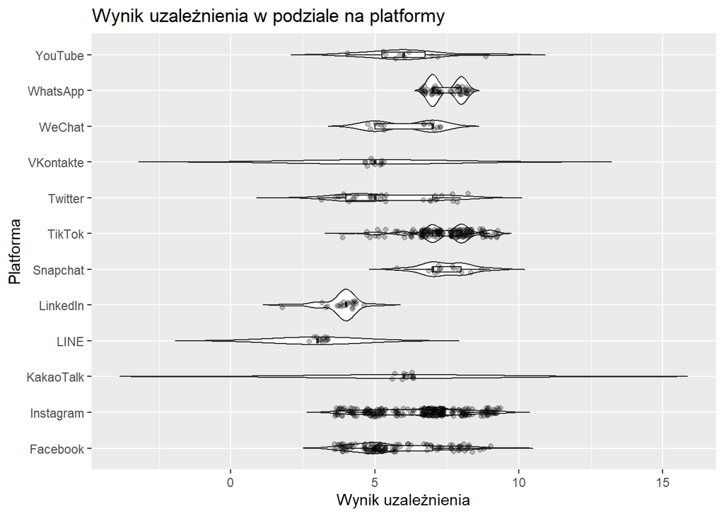

Wynik uzaleznienia vs platforma

```r
ggplot(data3, aes(x = platforma, y = wynik_uzaleznienia)) +
  geom_violin(trim = FALSE) +
  geom_boxplot(width = 0.15, outlier.shape = NA) +
  geom_jitter(width = 0.12, alpha = 0.25) +
  coord_flip() +
  labs(
    title = "Wynik uzależnienia w podziale na platformy",
    x = "Platforma",
    y = "Wynik uzależnienia"
  )
```

Sprawdziłem warunki ANOVA i wyszło, że normalność i jednorodność wariancji nie są spełnione (p-value < 0,001). Dlatego zamiast ANOVA użyłem testu Kruskala–Wallisa. Wynik był bardzo istotny ≈ 227,40, p-value jest ekstremalnie małe, więc poziom uzależnienia różni się między platformami. To znaczy, że nie wszystkie aplikacje „działają tak samo” pod względem wyniku uzależnienia.

## 5.6 Model regresja liniowa dla snu

```r
model_sen <- lm( sen_godz ~ czas_sm_godz + wiek + plec + zdrowie_psychiczne + wplywa_na_nauke, data = data3 )
data3_cent <- data3 %>%
  mutate( czas_sm_godz_c = as.numeric(scale(czas_sm_godz, center = TRUE, scale = FALSE)),
          wiek_c = as.numeric(scale(wiek, center = TRUE, scale = FALSE)),
          zdrowie_psychiczne_c = as.numeric(scale(zdrowie_psychiczne, center = TRUE, scale = FALSE))
          )

model_sen_c <- lm( sen_godz ~ czas_sm_godz_c + wiek_c + plec + zdrowie_psychiczne_c + wplywa_na_nauke,
                   data = data3_cent )

kable(broom::tidy(model_sen_c)) %>%
  kable_styling(full_width = FALSE, position = "left")
```

| term | estimate | std.error | statistic | p.value |
| --- | --- | --- | --- | --- |
| (Intercept) | 7.0872512 | 0.0686545 | 103.2306934 | 0.0000000 |
| czas_sm_godz_c | -0.5588780 | 0.0338066 | -16.5316409 | 0.0000000 |
| wiek_c | 0.0256964 | 0.0211437 | 1.2153235 | 0.2246530 |
| plecMale | -0.0508096 | 0.0585278 | -0.8681272 | 0.3856226 |
| zdrowie_psychiczne_c | 0.1024159 | 0.0491021 | 2.0857742 | 0.0373612 |
| wplywa_na_naukeYes | -0.3002806 | 0.0899518 | -3.3382390 | 0.0008878 |

```r
  vif_wynik <- vif(model_sen)
  vif_tab <- data.frame(
  Zmienna = names(vif_wynik),
  VIF = as.numeric(vif_wynik)
)
kable(vif_tab, align = "l") %>%
  kable_styling(full_width = FALSE, position = "left")
```

| Zmienna | VIF |
| --- | --- |
| czas_sm_godz | 2.817355 |
| wiek | 1.364673 |
| plec | 1.337140 |
| zdrowie_psychiczne | 4.590551 |
| wplywa_na_nauke | 2.901704 |

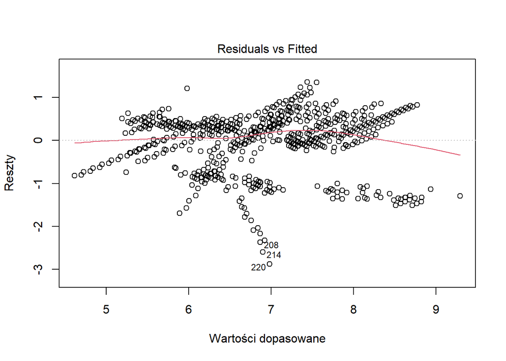

Model regresja liniowa dla snu

```r
# Wykres diagnostyczny dla "reszty vs dopasowanie", "Q-Q", "odstających punktów"
diag_plot <- function(ktory, x, y) {
  plot(model_sen, which = ktory, ann = FALSE, sub.caption = "")
  title(xlab = x, ylab = y)
}

# Teraz wywołanie przejdzie gładko:
diag_plot(1, "Wartości dopasowane", "Reszty")
```

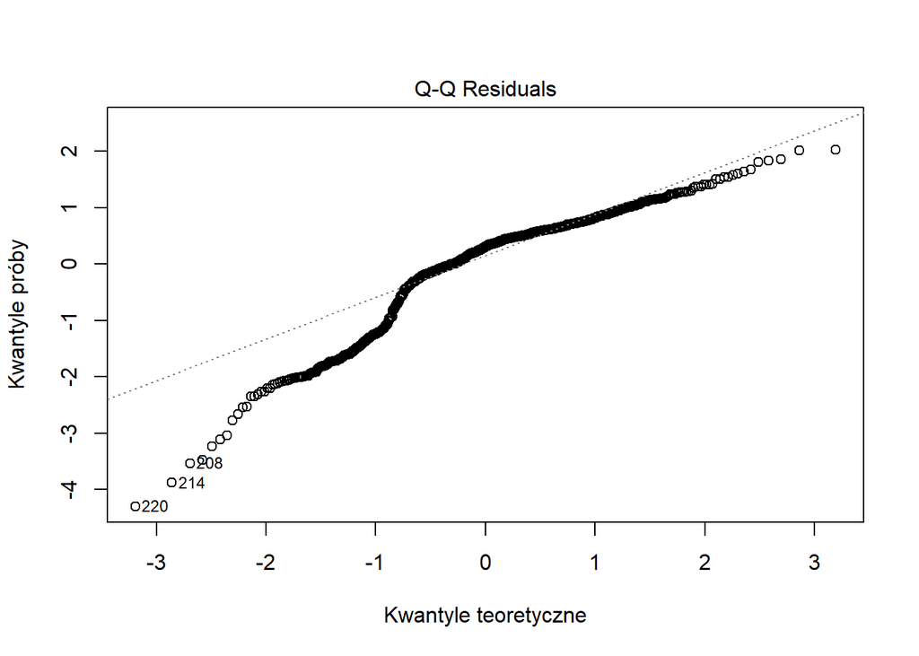

Model regresja liniowa dla snu

```r
diag_plot(2, "Kwantyle teoretyczne", "Kwantyle próby")
```

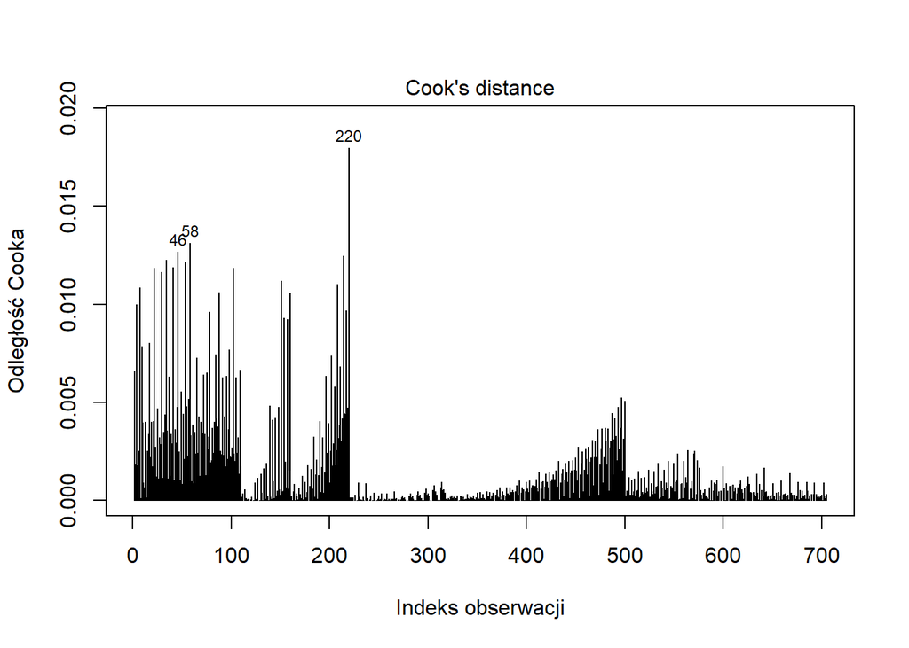

Model regresja liniowa dla snu

```r
diag_plot(4, "Indeks obserwacji", "Odległość Cooka")
```

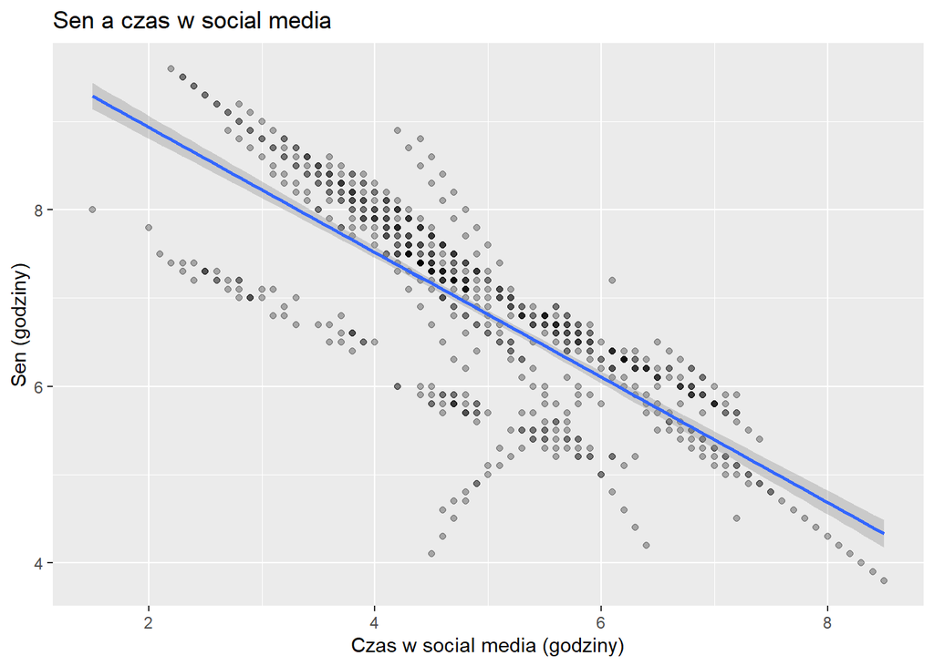

Model regresja liniowa dla snu

```r
ggplot(data3, aes(x = czas_sm_godz, y = sen_godz)) +
  geom_point(alpha = 0.3) +
  geom_smooth(method = "lm", formula = y ~ x, se = TRUE) +
  labs(
    x = "Czas w social media (godziny)",
    y = "Sen (godziny)",
    title = "Sen a czas w social media"
  )
```

Zbudowałem model liniowy dla snu i użyłem wersji z centrowaniem zmiennych. Najmocniejszy wpływ ma czas w social mediach. Współczynnik ≈ -0,559 (p-value < 0,001), czyli więcej social mediów oznacza mniej snu. Zdrowie psychiczne ma dodatni wpływ ≈ 0,102, p-value ≈ 0,037, czyli lepszy wynik zdrowia psychicznego wiąże się z dłuższym snem. Sama odpowiedź „Yes” ma dodatkowy negatywny efekt ≈ -0,300 (p-value < 0,001). Wiek i płeć w tym modelu nie były istotne.

Sprawdziłem też VIF i wartości nie są wysokie wynosi około 4,590, więc nie wygląda to na problem silnej współliniowości.

## 5.7 Testy dla grup snu

```r
# Sprawdzenie normalności Shapiro Wilk
p_sen <- tapply(data3$wynik_uzaleznienia, data3$niski_sen, \(x) shapiro.test(x)$p.value)

# Tabelka z p-value Shapiro Wilk
p_sen_tab <- data.frame(
  grupa = names(p_sen),
  p_value = format.pval(as.numeric(p_sen), digits = 3, eps = 0.001)
)
kable(p_sen_tab, align = "l") %>%
  kable_styling(full_width = FALSE, position = "left")
```

| grupa | p_value |
| --- | --- |
| <7h | <0.001 |
| >=7h | <0.001 |

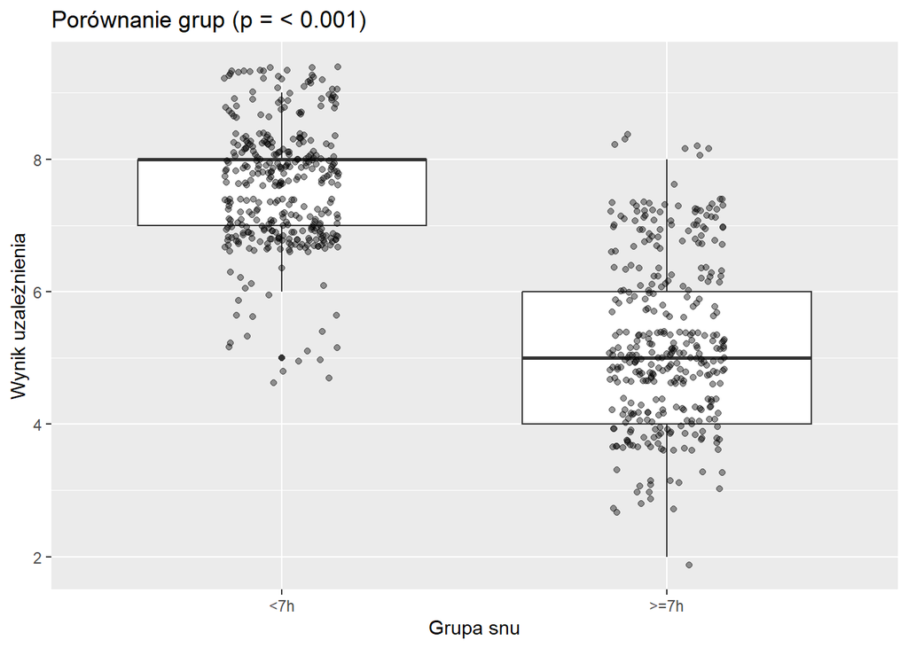

Wykres dla uzaleznienia w grupach snu (<7h vs >=7h)

```r
# Wybór testu
if(all(p_sen > 0.05)) {
  wynik_sen <- t.test(wynik_uzaleznienia ~ niski_sen, data = data3)
} else {
  wynik_sen <- wilcox.test(wynik_uzaleznienia ~ niski_sen, data = data3)
}

# Boxplot + Punkty
p_wykres <- format.pval(wynik_sen$p.value, eps = 0.001)

ggplot(data3, aes(x = niski_sen, y = wynik_uzaleznienia)) +
  geom_boxplot() +
  geom_jitter(width = 0.15, alpha = 0.4) +
  labs(
    x = "Grupa snu",
    y = "Wynik uzależnienia",
    title = paste0("Porównanie grup (p = ", p_wykres, ")")
  )
```

```r
# Statystyki opisowe
med_7mniej  <- median(data3$wynik_uzaleznienia[data3$niski_sen == "<7h"])
med_7wiecej <- median(data3$wynik_uzaleznienia[data3$niski_sen == ">=7h"])

mean_7mniej  <- mean(data3$wynik_uzaleznienia[data3$niski_sen == "<7h"])
mean_7wiecej <- mean(data3$wynik_uzaleznienia[data3$niski_sen == ">=7h"])

wyniki_opis <- data.frame(
  grupa = c("<7h", ">=7h"),
  mediana = c(med_7mniej, med_7wiecej),
  srednia = c(mean_7mniej, mean_7wiecej)
)



kable(wyniki_opis, align = "l") %>%
  kable_styling(full_width = FALSE, position = "left")
```

| grupa | mediana | srednia |
| --- | --- | --- |
| <7h | 8 | 7.593315 |
| >=7h | 5 | 5.236994 |

```r
# Wynik testu i p-value
broom::tidy(wynik_sen) %>%
  mutate(p.value = format.pval(p.value, eps = 0.001)) %>%
  t() %>%
  kable() %>%
  kable_styling(full_width = FALSE, position = "left")
```

| statistic | 114828.5 |
| --- | --- |
| p.value | < 0.001 |
| method | Wilcoxon rank sum test with continuity correction |
| alternative | two.sided |

Porównałem poziom uzależnienia między osobami śpiącymi <7h i ≥7h. Ponieważ rozkłady nie były normalne, użyłem testu Wilcoxona. Wynik wyszedł istotny (p < 0,001), więc grupy różnią się poziomem uzależnienia.

W praktyce osoby śpiące <7h mają wyższy wynik uzależnienia średnia 7,59 i mediana 8. Osoby śpiące ≥7h mają niższy wynik średnia 5,24 i mediana 5. To wygląda jak mocne powiązanie krótkiego snu z większym uzależnieniem.

## 5.8 Model logit dla wpływu na naukę

```r
# Przygotowanie zmiennej 0/1 (Yes = 1, No = 0)

data_logit <- data3 %>%
  mutate(wplyw01 = if_else(wplywa_na_nauke == "Yes", 1, 0))

# Model logitowy
model_logit <- glm(
  wplyw01 ~ czas_sm_godz + sen_godz + wiek + plec,
  data = data_logit,
  family = binomial
)

# Wyniki modelu
wynik_logit <- broom::tidy(model_logit)
kable(wynik_logit, align = "l") %>%
  kable_styling(full_width = FALSE, position = "left")
```

| term | estimate | std.error | statistic | p.value |
| --- | --- | --- | --- | --- |
| (Intercept) | 4.0210710 | 2.8362961 | 1.417719 | 0.1562728 |
| czas_sm_godz | 1.9187998 | 0.2392080 | 8.021472 | 0.0000000 |
| sen_godz | -0.7388945 | 0.1928143 | -3.832156 | 0.0001270 |
| wiek | -0.3442593 | 0.1074530 | -3.203813 | 0.0013562 |
| plecMale | 0.4245137 | 0.2765662 | 1.534944 | 0.1247976 |

```r
# Współczynniki regresji (OR)
or_tab <- data.frame(
  Zmienna = names(coef(model_logit)),
  OR = exp(coef(model_logit))
)
kable(or_tab, align = "l", row.names = FALSE) %>%
  kable_styling(full_width = FALSE, position = "left")
```

| Zmienna | OR |
| --- | --- |
| (Intercept) | 55.7607947 |
| czas_sm_godz | 6.8127769 |
| sen_godz | 0.4776417 |
| wiek | 0.7087451 |
| plecMale | 1.5288467 |

Zrobiłem model logitowy, który przewiduje odpowiedź „Yes/No” (wpływ na naukę) na podstawie czasu w social mediach, snu, wieku i płci. Najsilniejszy czynnik to czas korzystania: jest istotny i ma duży efekt OR ≈ 6,812. Czyli każda dodatkowa godzina mocno zwiększa szansę odpowiedzi „Yes”.

Sen działa odwrotnie OR ≈ 0,477 istotne), więc więcej snu zmniejsza szansę deklarowania wpływu. Wiek też zmniejsza szansę OR ≈ 0,71 istotne. Płeć nie wyszła istotna (p-value > 0,05), więc w tym modelu nie widać różnicy między kobietami i mężczyznami.

# 6. Podsumowanie i wnioski końcowe

W danych nie było braków ani duplikatów, więc analiza była prosta technicznie. Najwięcej osób korzysta z social mediów 4–6 godzin dziennie bo aż 393 osoby, a prawie połowa śpi poniżej 7 godzin, 359 osób. Większość ankietowanych 453 osób deklaruje, że social media wpływają na ich naukę.

Najważniejsze wyniki są spójne: czas w social mediach jest bardzo silnie powiązany z krótszym snem rho = -0,814 i wyższym uzależnieniem rho = 0,838. Grupa „Yes” realnie różni się od „No” ma więcej godzin social mediów, mniej snu i wyższy wynik uzależnienia. Test Wilcoxona potwierdził, że różnica w śnie jest istotna, a efekt jest duży.

Widać też różnice uzależnienia między platformami dzięki testowi Kruskal–Wallis istotności. Model liniowy pokazał, że najważniejszy czynnik dla snu to czas w social mediach, a dodatkowo znaczenie mają zdrowie psychiczne i sama deklaracja wpływu na naukę. Model logitowy pokazał, że największy wpływ na odpowiedź „Yes” ma czas korzystania, a ochronnie działa sen i wiek. Ogólnie wnioski są jasne: większe korzystanie z social mediów idzie w parze z gorszym snem i wyższym uzależnieniem, szczególnie u osób, które same czują wpływ na naukę.